# Clean(ish) Code: `dupree`

## Presented to EdinbR R-Users Group, 2019-07-17

Russ Hyde, University of Glasgow

## Background and Links:

### Today’s packages

- https://github.com/russHyde/dupree
- https://github.com/jimhester/lintr
- [`https://github.com/ropensci/git2r`](https://github.com/ropensci/git2r)

### Me

- https://twitter.com/haematobot
- https://russ-hyde.rbind.io/
- [Paul O’Gorman Leukaemia Research Centre](https://www.gla.ac.uk/connect/supportus/medicalfund/paulogormanleukaemiaresearchcentre/)

## Preamble

```r
# Dependencies:
# - lintr, dplyr, purrr, tibble, magrittr, methods, stringdist
if (!"dupree" %in% installed.packages()) {
  require("devtools")
  devtools::install_github(
    repo = "russHyde/dupree", dependencies = FALSE
  )
}

suppressPackageStartupMessages({
  library(lintr)
  library(dupree)
  library(git2r)
})
```

## Code Smells & Architectural Ideals

*"The most common design problems result from code that*

- *Is duplicated*
- *Is unclear*
- *Is complicated"*

Quote: Kerievsky ‘Refactoring to Patterns’

See also Fowler ‘Refactoring’, Martin ‘Clean Code’ and Jenny Bryan’s talk ‘Code smells and feels’

## Types of duplication

[figure not shown]

- Trivial stuff (`library(dplyr)`)
- Copy/paste-driven development (similar logic & code)
- Functional duplication (same logic, different code)
- ? False duplication (different logic, similar code)

## How to detect duplication?

- Python
  - `pylint` (looks for identical *lines* between files)
- Java / C++ / C# etc
  - lots of choice (code structure / identity)
- R: nothing for source code (AFAIK)
  - String / Sequence similarity: `stringdist`
  - Text analysis: `ropensci:textreuse`
  - (But tools like: `goodpractice`, `lintr`, `styler`, `cyclocomp`, `pkgnet`)

## `dupree`

- https://github.com/russHyde/dupree
- All community input is welcome
- Most data input is welcome:
  - sets of files (`dupree()`)
  - a directory (`dupree_dir()`)
  - or a package (`dupree_package()`)

## Duplication in a script

```r
# min_block_size: used to prevent dupree analysing really small code blocks
dupree("duplication_heavy.R", min_block_size = 3) %>%
  dplyr::select(-file_a, -file_b)
```

| block_a | block_b | line_a | line_b | score |
| --- | --- | --- | --- | --- |
| 3 | 4 | 4 | 9 | 0.7777778 |
| 4 | 3 | 9 | 4 | 0.7777778 |
| 5 | 4 | 17 | 9 | 0.5161290 |

[output not shown]

3 rows

## Duplication in a script (cont.)

```r
library(dplyr)
data(diamonds)

diamonds %>%
  filter(clarity %in% c("SI1", "SI2")) %>%
  group_by(color) %>%
  summarise(m_price = mean(price), sd_price = sd(price))

diamonds %>%
  filter(cut >= "Very Good") %>%
  group_by(color) %>%
  summarise(m_price = mean(price), sd_price = sd(price))


# note that dupree can't tell that the following code is logically
# the same as the preceding code
summarise(
  group_by(
    filter(diamonds, cut >= "Very Good"),
    color
  ),
  sd_price = sd(price),
  m_price = mean(price)
)
```

## Mechanics

Longest Common Substring

```r
# breakf-a---st
# break-dance--
stringdist::stringdist("breakfast", "breakdance", method = "lcs")
```

```
## [1] 7
```

Code blocks

-> Sentences of function / variable names

-> “Sentences” of integers

-> Compute similarity score based on longest-common-subsequence

## Mechanics (cont.)

Use `seq_sim` to compute LCS-based distance between vectors of integers

```r
to_ints <- function(word){
  as.integer(factor(strsplit(word, "")[[1]], levels = letters))
}

to_ints("breakfast")
```

```
## [1]  2 18  5  1 11  6  1 19 20
```

```r
stringdist::seq_sim(
  list(to_ints("breakfast")), list(to_ints("breakdance")), method = "lcs"
) # 1 - |LCS| / (|seq1| + |seq2|)
```

```
## [1] 0.6315789
```

## Duplication in a package

Downloaded the source code for `lintr` from github using [`ropensci/git2r`](https://github.com/ropensci/git2r).

```r
# temporary dir for storing `lintr`'s source code
lintr_path <- file.path(tempdir(), "lintr")
lintr_repo <- git2r::clone(
  "https://github.com/jimhester/lintr",
  lintr_path
)
```

## Duplication in a package (cont)

Ran dupree on `lintr`

```r
dups <- dupree::dupree_package(
  lintr_path, min_block_size = 40
)
```

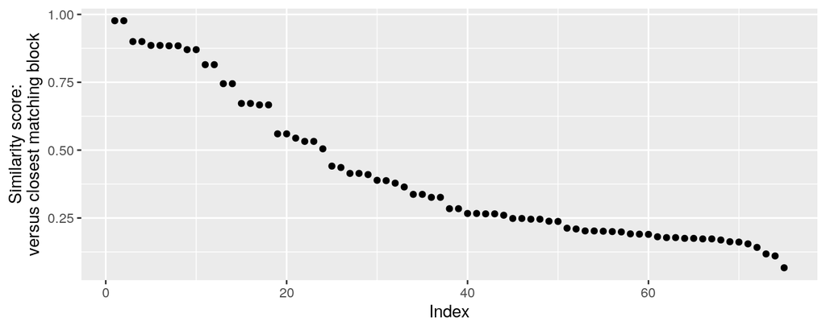

## Duplication in a package (cont)

```r
dups %>%
  dplyr::filter(score > 0.4 & file_a != file_b) %>%
  dplyr::mutate_at(c("file_a", "file_b"), basename) %>%
  head()
```

| file_a | file_b | block_a | block_b | line_a | line_b | score |
| --- | --- | --- | --- | --- | --- | --- |
| equals_na_lintr.R | no_tab_linter.R | 1 | 1 | 3 | 3 | 0.8857143 |
| no_tab_linter.R | equals_na_lintr.R | 1 | 1 | 3 | 3 | 0.8857143 |
| function_left_parentheses.R | spaces_left_parentheses_linter.R | 1 | 1 | 4 | 4 | 0.8844221 |
| spaces_left_parentheses_linter.R | function_left_parentheses.R | 1 | 1 | 4 | 4 | 0.8844221 |
| undesirable_function_linter.R | undesirable_operator_linter.R | 1 | 2 | 6 | 16 | 0.8148148 |
| undesirable_operator_linter.R | undesirable_function_linter.R | 2 | 1 | 16 | 6 | 0.8148148 |

[output not shown]

6 rows | 1-4 of 7 columns

[GOTO: `equals_na_lintr.R`](https://github.com/jimhester/lintr/blob/master/R/equals_na_lintr.R)

## Visualisation of duplication results

We make a tidygraph structure from the similarity scores

```r
dup_graph <- dups %>%
  # keep code-block pairs with moderate similarity:
  dplyr::filter(score > 0.4) %>%
  dplyr::transmute(
    # indicate code-blocks by filename and start-line
    from = paste(basename(file_a), line_a),
    to = paste(basename(file_b), line_b),
    type = "duplication",
    score = score
  ) %>%
  tidygraph::as_tbl_graph() %>%
  # distinguish the file each code block came from
  mutate(filename = gsub("(.*) \\d+$", "\\1", name))
```

## Visualisation of duplication results (cont)

```r
graph_image <- dup_graph %>%
  ggraph(layout = "gem") +
  geom_edge_link(
    aes(colour = type, edge_width = score)
  ) +
  geom_node_point(
    aes(colour = filename), size = 4, show.legend = FALSE
  ) +
  theme_graph()
```

## Visualisation of duplication results (cont)

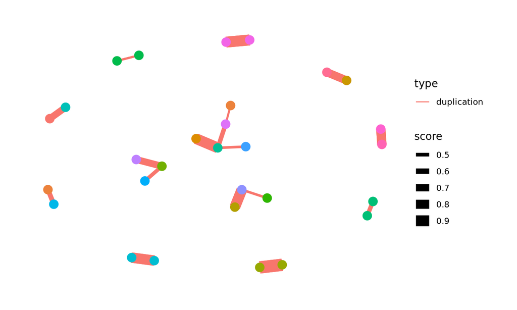

```r
graph_image
```

## Visualisation of duplication results (cont)

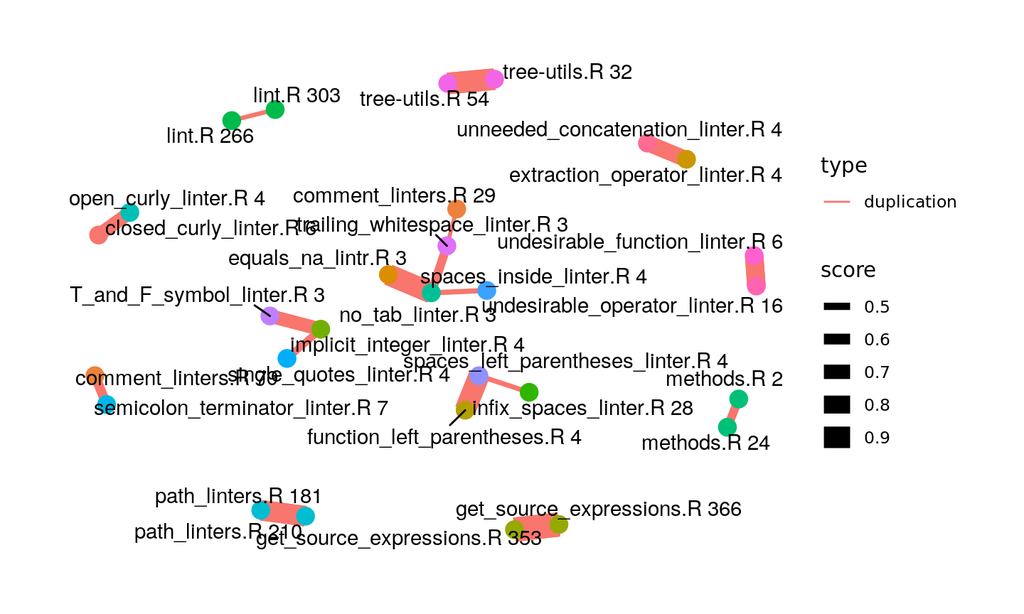

```r
graph_image +
  geom_node_text(aes(label = name), repel = TRUE)
```

## What was `lintr` by the way?

- style / syntax checker for *R*
- configurable
- can be ran
  - in Rstudio / vim / atom etc
  - or on Travis
- (and dupree uses lintr’s file parsers)

## refactoRing

- Improving the structure of code (without modifying its function)
- The rule of 3
- Examples
  - Figures: Global theming / %+%
  - Statements: Replace with function call
  - Common functions: Move to a package
  - RMarkdown: Configurable reports / child-stubs